# Lab 4: Childcare Costs in California

- Show All Code
- Hide All Code
- View Source

Author

Miriam Rosen

## The Data

In this lab we’re going look at the median weekly cost of childcare in California. A detailed description of the data can be found [here](https://github.com/rfordatascience/tidytuesday/blob/master/data/2023/2023-05-09/readme.md).

The data come to us from [TidyTuesday](https://github.com/rfordatascience/tidytuesday).

**0. Load the appropriate libraries and the data.**

```r
library(tidyverse)
```

```r
childcare_costs <- read_csv('https://raw.githubusercontent.com/rfordatascience/tidytuesday/master/data/2023/2023-05-09/childcare_costs.csv')

counties <- read_csv('https://raw.githubusercontent.com/rfordatascience/tidytuesday/master/data/2023/2023-05-09/counties.csv')

# glimpse(childcare_costs)
# glimpse(counties)
```

Reflection: I originally had glimpse() in the beginning of my report, but this is not necessary and I now realize this clutters the beginning of my report.

**1. Briefly describe the dataset (~ 4 sentences). What information does it contain?**

The data set, childcare_costs, is a comprehensive source of childcare costs at county levels. The data comes from the National Database of Childcare Prices (NDCP) and includes data from 2008 to 2018. The data set includes information regarding demographics of childcare providers, age of children, and characteristics of the county. The data set has 34567 rows and 61 columns. Each row correlates to a specific county in a specific year.

## California Childcare Costs

Let’s start by focusing only on California.

**2. Create a `ca_childcare` dataset of childcare costs in California, containing (1) county information and (2) all information from the `childcare_costs` dataset.** *Hint: There are 58 counties in CA and 11 years in the dataset. Therefore, your new dataset should have 53 x 11 = 638 observations.*

```r
ca_childcare <- counties |>
  filter(state_abbreviation == "CA") |>
  right_join(childcare_costs,
             by = "county_fips_code"
             )
```

**3. Using a function from the `forcats` package, complete the code below to create a new variable where each county is categorized into one of the [10 Census regions](https://census.ca.gov/regions/) in California. Use the Region description (from the plot), not the Region number.**  
*Hint: This is probably a good place to use ChatGPT to reduce on tedious work. But you do need to know how to prompt ChatGPT to make it useful!*

```r
ca_childcare <- ca_childcare |>
 mutate(county_name = str_remove(county_name, " County")) |>
  mutate(region = fct_collapse(county_name,
                               "Superior California" = c("Butte",
                                                         "Colusa",
                                                         "El Dorado",
                                                         "Glenn",
                                                         "Lassen",
                                                         "Modoc",
                                                         "Nevada",
                                                         "Placer",
                                                         "Plumas",
                                                         "Sacramento",
                                                         "Shasta",
                                                         "Sierra",
                                                         "Siskiyou",
                                                         "Sutter",
                                                         "Tehama",
                                                         "Yolo",
                                                         "Yuba"
                                                         ),
                               "North Coast" = c("Del Norte",
                                                 "Humboldt",
                                                 "Lake",
                                                 "Mendocino",
                                                 "Napa", "Sonoma",
                                                 "Trinity"
                                                 ),
                               "San Francisco Bay Area" = c("Alameda",
                                                            "Contra Costa",
                                                            "Marin",
                                                            "San Francisco",
                                                            "San Mateo",
                                                            "Santa Clara",
                                                            "Solano"
                                                            ),
                               "Northern San Joaquin Valley" = c("Alpine",
                                                                 "Amador",
                                                                 "Calaveras",
                                                                 "Madera",
                                                                 "Mariposa",
                                                                 "Merced",
                                                                 "Mono",
                                                                 "San Joaquin", "Stanislaus",
                                                                 "Tuolumne"
                                                                ),
                               "Central Coast" = c("Monterey",
                                                   "San Benito",
                                                   "San Luis Obispo",
                                                   "Santa Barbara",
                                                   "Santa Cruz",
                                                   "Ventura"
                                                   ),
                               "Southern San Joaquin Valley" = c("Fresno",
                                                                 "Inyo",
                                                                 "Kern",
                                                                 "Kings",
                                                                 "Tulare"
                                                                 ),
                               "Inland Empire" = c("Riverside",
                                                   "San Bernardino"
                                                         ),
                               "Los Angeles County" = c("Los Angeles"),
                               "Orange County" = c("Orange"),
                               "San Diego - Imperial" = c("San Diego",
                                                    "Imperial"
                                                    )
                               )
         )
```

**4. Let’s consider the median household income of each region, and how that income has changed over time. Create a table with ten rows, one for each region, and two columns, one for 2008 and one for 2018. The cells should contain the `median` of the median household income (expressed in 2018 dollars) of the `region` and the `study_year`. Arrange the rows by 2018 values.**

```r
ca_childcare |>
  select(region,
         study_year,
         mhi_2018
         ) |>
  filter(study_year %in% c(2008,
                           2018
                           )
         ) |>
  group_by(region, study_year) |>
  summarize(median_household_income = median(mhi_2018),
            .groups = "drop") |>
  pivot_wider(names_from = study_year,
              values_from = median_household_income) |>
  arrange(desc(`2008`),
          desc(`2018`
              )
          ) |>
  rename(`Median Household Income in 2008` = `2008`,
         `Median Household Income in 2018` = `2018`
         ) |>
  drop_na()
```

```
# A tibble: 10 × 3
   region                      Median Household Income …¹ Median Household Inc…²
   <fct>                                            <dbl>                  <dbl>
 1 San Francisco Bay Area                          90412.                104552
 2 Orange County                                   86452.                 85398
 3 Central Coast                                   72979                  74849
 4 Inland Empire                                   65977.                 62056
 5 Los Angeles County                              63471.                 64251
 6 Northern San Joaquin Valley                     59108.                 57769
 7 San Diego - Imperial                            58201.                 60344.
 8 Superior California                             57831.                 53270
 9 Southern San Joaquin Valley                     52676.                 52479
10 North Coast                                     47862.                 45528
# ℹ abbreviated names: ¹`Median Household Income in 2008`,
#   ²`Median Household Income in 2018`
```

Reflection: In this revision, I renamed the two new columns made to be more descriptive of what the rows entail. Originally, I simply named them 2008 and 2018, but realized that these column names do not provide the reader with any details regarding what the columns contain. It is important that I use descriptive names so that if someone is looking at this data frame, they are able to easily understand what it is showing.

**5. Which California `region` had the lowest `median` full-time median weekly price for center-based childcare for infants in 2018? Does this `region` correspond to the `region` with the lowest `median` income in 2018 that you found in Q4?**  
*Hint: The code should give me the EXACT answer. This means having the code output the exact row(s) and variable(s) necessary for providing the solution.*

```r
ca_childcare |>
  filter(study_year == 2018) |>
  group_by(region) |>
  summarize(median_childcare_price_infants = median(mc_infant,
                                                    na.rm = TRUE
                                                    )
            ) |>
  drop_na() |>
  slice_min(order_by = median_childcare_price_infants,
            n = 1
            )
```

```
# A tibble: 1 × 2
  region              median_childcare_price_infants
  <fct>                                        <dbl>
1 Superior California                           215.
```

```r
ca_childcare |>
   filter(study_year == 2018) |>
   group_by(region) |>
   summarize(median_income_by_region = median(mhi_2018,
                                              na.rm = TRUE
                                              )
             ) |>
   slice_min(order_by = median_income_by_region,
             n = 1
             )
```

```
# A tibble: 1 × 2
  region      median_income_by_region
  <fct>                         <dbl>
1 North Coast                   45528
```

The region with the lowest median full time median weekly price for center based childcare for infants in 2018 is Superior California. The region with the lowest median household income for 2018 was the North Coast.

Reflection: Originally, I did not correctly understand what the question was asking for. I did not realize we were looking at a different variable that contains information on the cost for childcare and comparing it to median household income by region. In my revision, I used the summarize function to get the median weekly price for center-based childcare for infants in 2018 and then used the slice_min() function to get the region with the lowest median cost for center-base childcare for infants in 2018. Then, I summarized the median household income in 2018 by region and used the slice_min() function to get the region with the lowest median household income in 2018. For the future, I need to make sure I am using the right variables so that the summarizing I am doing is producing the correct information.

**6. The following plot shows, for all ten regions, the change over time of the full-time median price for center-based childcare for infants, toddlers, and preschoolers. Recreate the plot. You do not have to replicate the exact colors or theme, but your plot should have the same content, including the order of the facets and legend, reader-friendly labels, axes breaks, and a loess smoother.**

Plot to recreate

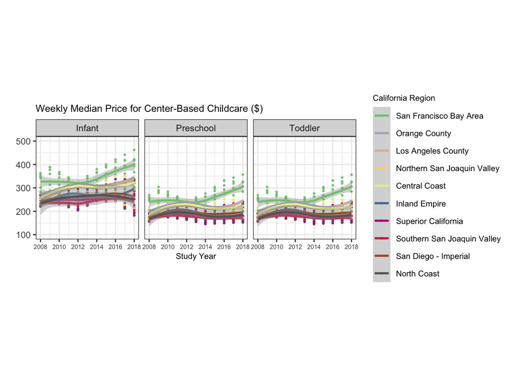

```r
library(scales)
library(RColorBrewer)

custom <-colorRampPalette(brewer.pal(8, "Accent"))(10)

ca_childcare |>
  select(study_year,
         mc_infant,
         mc_toddler,
         mc_preschool,
         region
         ) |>
  rename(Infant = mc_infant,
         Toddler = mc_toddler,
         Preschool = mc_preschool
         ) |>
  pivot_longer(cols = c("Infant",
                       "Toddler",
                       "Preschool"
                       ),
               names_to = "age",
               values_to = "median_income"
               ) |>
  mutate(fct_relevel(age, "Infant",
                          "Toddler",
                          "Preschool")
        ) |>
  drop_na() |>
  ggplot(mapping = aes(x = study_year,
                          y = median_income,
                          color = fct_reorder2(region,
                                               study_year,
                                               median_income
                                               )
                          )
       ) +
  geom_point(size = 0.5) +
  geom_smooth() +
  facet_wrap(~ age) +
  labs(title = "Weekly Median Price for Center-Based Childcare ($)",
       x = "Study Year",
       y = "",
       color = "California Region"
       ) +
  scale_x_continuous(breaks = seq(2008,
                                  2018,
                                  by = 2,
                                  )
                     ) +
  scale_y_continuous(breaks = c(100,
                                200,
                                300,
                                400,
                                500
                                ),
                     limits = c(100,
                                500
                                )
                     ) +
  scale_color_manual(values = custom) +
  theme_bw() +
  theme(aspect.ratio = 1,
        axis.text.x = element_text(size = 6),
        legend.title = element_text(size = 8),
        legend.text = element_text(size = 8),
        title = element_text(size = 8)
        )
```

[output not shown]

```r
# https://chatgpt.com/share/672d6cf0-7e54-800c-b1c4-bffb51095c06 My colorRampPalette was returning an error. I asked chatgpt what was wrong with the code. Chatgpt explained that I needed to make a custom palette and then how use the scale_color_manual() function to apply my custom palette,fixing the issue of not having enough colors in my legend.
```

I also connected my dplyr pipeline to my ggplot to eliminate the need to pass an argument into the ggplot() function, meeting the criteria for PE-4 and making my code more efficient.

## Median Household Income vs. Childcare Costs for Infants

**7. Create a scatterplot showing the relationship between median household income (expressed in 2018 dollars) and the full-time median weekly price charged for center-based childcare for an infant in California. Overlay a linear regression line (lm) to show the trend.**

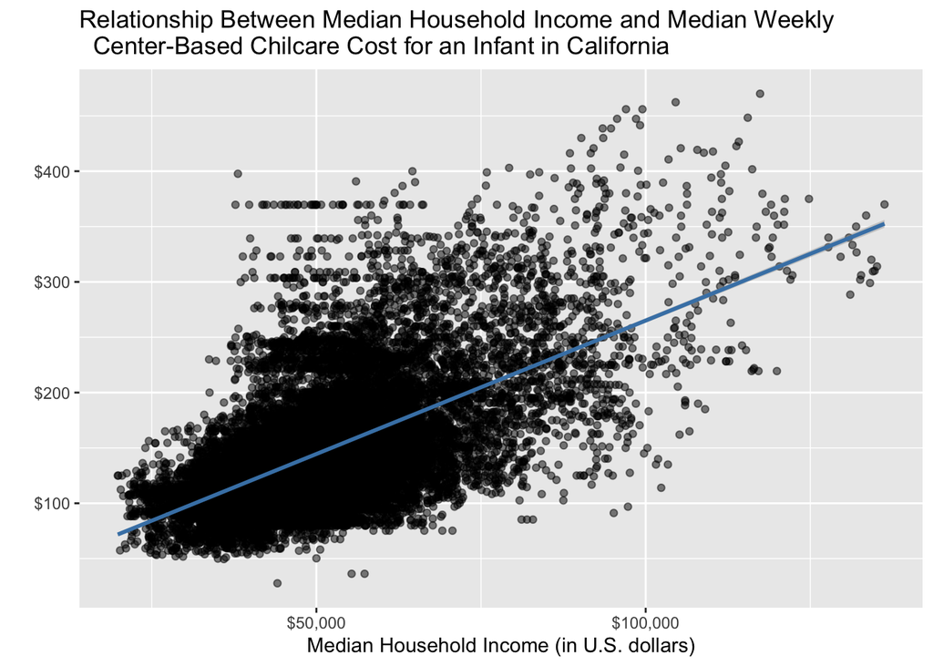

```r
ggplot(data = ca_childcare,
       mapping = aes(x = mhi_2018,
                     y = mc_infant
                     )
       ) +
  geom_point(alpha = 0.5) +
  geom_smooth(method = "lm",
              color = "steelblue"
              ) +
  labs(title = "Relationship Between Median Household Income and Median Weekly
  Center-Based Chilcare Cost for an Infant in California",
       x = "Median Household Income (in U.S. dollars)",
       y = ""
       ) +
  scale_x_continuous(labels = label_dollar()) +
  scale_y_continuous(labels = label_dollar())
```

Reflection: I incorporated the label_dollar() function from the scales package to add dollar signs and commas to the values on my x and y axis. This helps ensure the reader easily understands that these numbers are referring to U.S. dollars and makes my plot cleaner and more professional looking.

**8. Look up the documentation for `lm()` and fit a linear regression model to the relationship shown in your plot above.**

```r
# complete the code provided
reg_mod1 <- lm(mc_infant ~ mhi_2018,
               data = ca_childcare
               )


summary(reg_mod1)
```

```
Call:
lm(formula = mc_infant ~ mhi_2018, data = ca_childcare)

Residuals:
     Min       1Q   Median       3Q      Max
-162.197  -26.722   -4.853   18.639  281.898

Coefficients:
             Estimate Std. Error t value Pr(>|t|)
(Intercept) 2.398e+01  1.091e+00   21.99   <2e-16 ***
mhi_2018    2.411e-03  2.082e-05  115.79   <2e-16 ***
---
Signif. codes:  0 '***' 0.001 '**' 0.01 '*' 0.05 '.' 0.1 ' ' 1

Residual standard error: 42.88 on 23591 degrees of freedom
  (10974 observations deleted due to missingness)
Multiple R-squared:  0.3624,    Adjusted R-squared:  0.3624
F-statistic: 1.341e+04 on 1 and 23591 DF,  p-value: < 2.2e-16
```

**9. Using the output from `summary()`, write out the estimated regression line (recall: $y = mx + b$).**

mc_infant = 0.002411 x mhi_2018 + 23.98

**10. Do you have evidence to conclude there is a relationship between the median household income and the median weekly cost of center-based childcare for infants in California? Cite values from your `summary()` output to support your claim!**